# Presentation

2024-07-28

## Análisis de la Participación Electoral y la Confianza en Políticos

En este análisis, examinamos la relación entre la participación en las elecciones y la confianza en los políticos. Utilizamos un gráfico de barras para visualizar cómo varía la participación electoral según diferentes niveles de confianza en los políticos.

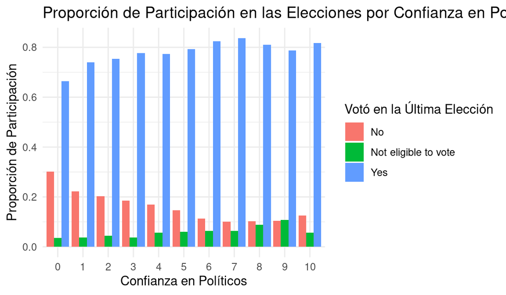

## Resultados

El gráfico de barras anterior muestra la distribución de la participación en las elecciones (sí, no, no elegible para votar) en relación con la confianza en los políticos. A partir de este gráfico, podemos observar lo siguiente:

Alta confianza en políticos: Los encuestados con alta confianza en los políticos tienden a tener una mayor participación en las elecciones. Baja confianza en políticos: Los encuestados con baja confianza en los políticos muestran una menor participación en las elecciones. Patrón general: A medida que aumenta la confianza en los políticos, la participación en las elecciones también tiende a aumentar, aunque existen algunas excepciones y variabilidad.

## Discusión

Estos resultados sugieren que la confianza en los políticos puede ser un factor importante en la participación electoral. Los individuos que confían más en los políticos parecen estar más motivados para votar, posiblemente porque creen en la efectividad del sistema político y en que su voto puede tener un impacto positivo.